# Presentation of Ancestral Reconstruction Results

J.P. Meagher

8 January 2018

# Introduction

We are given a dataset of $N$ bat echolocation call recordings denoted $\{y_n\}_{n = 1}^N$. This recording is then processed to produce a set of smooth surfaces over a regular grid denoted $\{\tilde{S}_n\}_{n=1}^{N}$. This surface is produced by smoothing the call spectrogram and mapping it to a regular grid over relevant frequencies and an absolute time scale Pigoli et al. (2015).

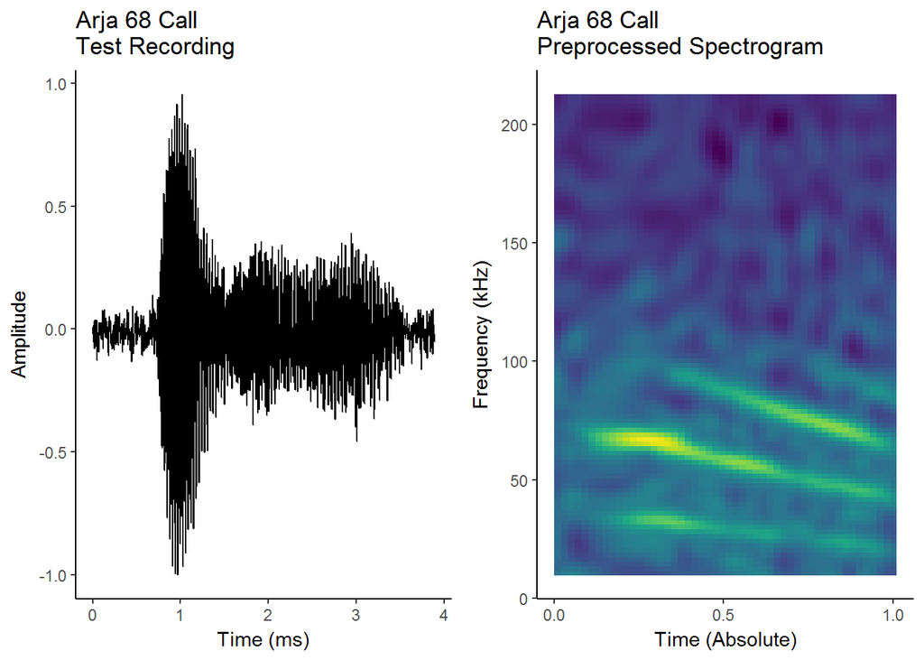

A randomly selected bat call from the species Arja alongside it’s corresponding smoothed surface representation. The smooth surface is obtained by taking the call spectrogram and treating it as a functional data object. The spectrogram is first smoothed by a robust 2-D spline smoother, then mapped to an absolute time scale and registered in time by a pairwise surface synchronisation, and finally restricted to the 9 - 212 kHz frequency spectrum.

Along with this dataset we are given a phylogeny defining the evolutionary relationships between the species of bat.

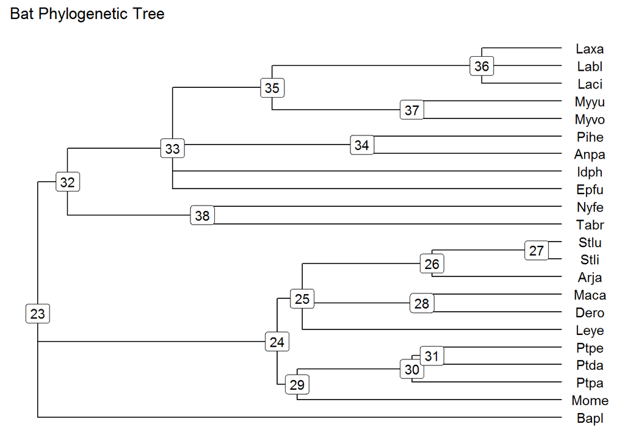

Tree of assumed evolutionary relationships between Bat Species. This phylogeny was transcribed from a recent bat super tree and shoud represent a ‘best guess’ for the evolutionary relationships between bat species based on the fossil record alongside morphological and molecular studies of evolutionary relationships.

A model has been developed to produce ancestral reconstructions for the smoothed spectrogram surfaces representing the echolocation calls of extinct bats and an audio file approximating the call that would correspond to such a spectrogram surface can also be produced.

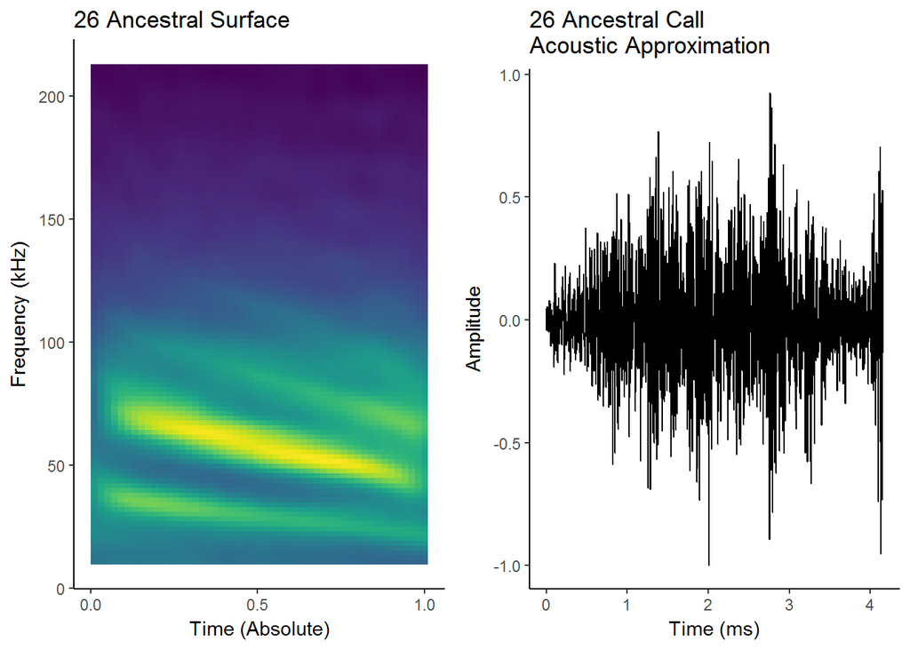

Ancestral spectrogram and acoustic approximation for the common ancestor of Arja, Stli, Stlu. The reconstruction is given by the MAP estimates for the weight of each evolutionary feature at the node. In this case, evolutionary features were identified by a PCA of the smoothed spectrogram surfaces. The acoustic reconstruction was performed assuming a call duration of approximately 4 ms

Thus, for the dataset of Mexican Bat echolocation calls and the given Phylogeny, Ancestral Reconstruction has been performed.

# The Current Model

# A Joint model for spectrogram surfaces

Pigoli, Davide, Pantelis Z Hadjipantelis, John S Coleman, and John AD Aston. 2015. “The Analysis of Acoustic Phonetic Data: Exploring Differences in the Spoken Romance Languages.” *arXiv Preprint arXiv:1507.07587*.